[figure not shown]

Class 5: Data Viz with ggplot

Sze Sze (PID 167)

Quarto

To learn more about Quarto see https://quarto.org.

Running Code

Intro to ggplot

plot(1:10)

1

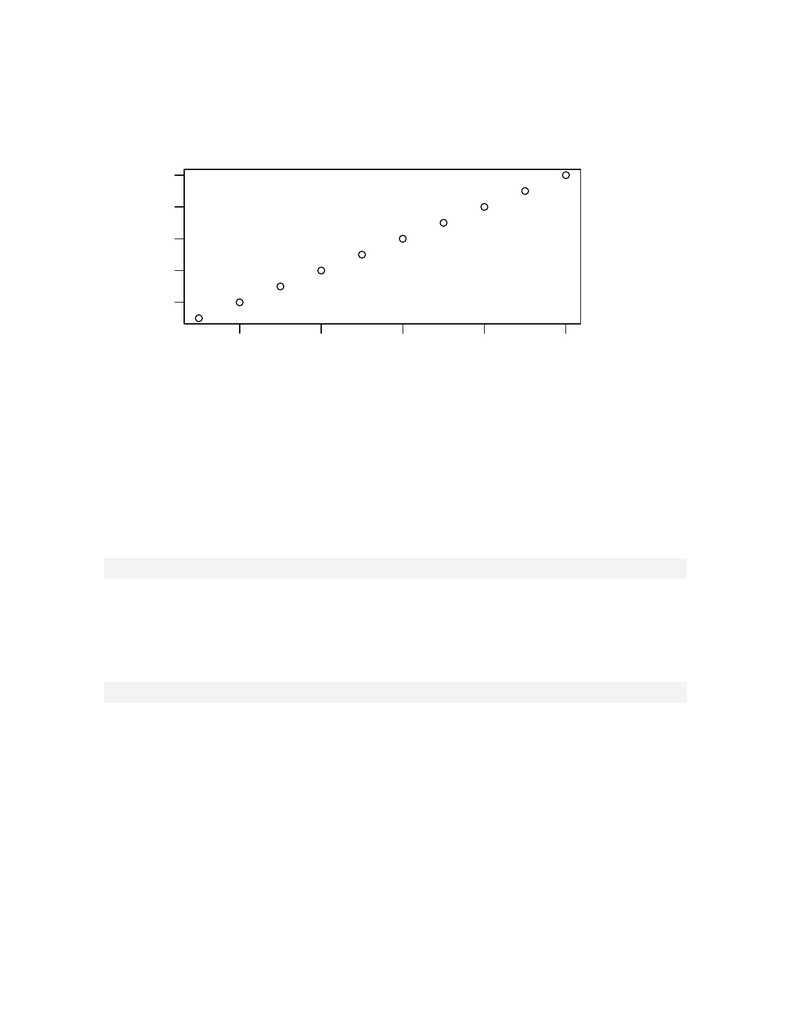

2 4 6 8 10

2 4 6 8 10

Index

1:10

‘install.packages()’

> I will run ’install.packages(“ggplot2”) in my R console not this quarto document!

#ggplot(cars)

Let’s see how we can make this gure using ggplot

“library()” with the library(ggplot2) call.

library(ggplot2)

All ggplot gures have at least 3 things (called layers). These include”

-data data (the input dataset I want to plot from) -aes (the aesthetic mapping of gthe data

to my plot) -geoms (the geom_point(), geom_line() etc. that I want to draw).

2

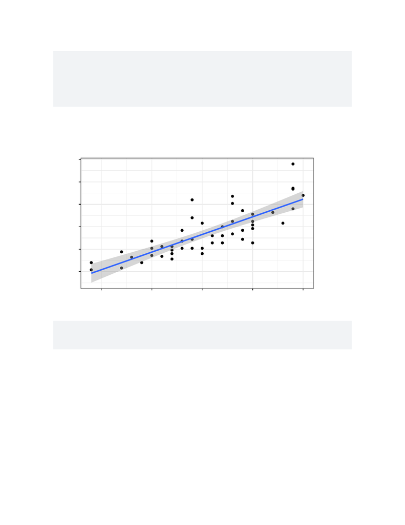

ggplot(cars) +

aes(x=speed, y=dist) +

geom_point() +

geom_smooth(method="lm") +

theme_bw()+

labs(title="My first GGPLOT")

`geom_smooth()` using formula = 'y ~ x'

0

25

50

75

100

125

5 10 15 20 25

speed

dist

My first GGPLOT

url <- "https://bioboot.github.io/bimm143_S20/class-material/up_down_expression.txt"

genes <- read.delim(url)

head(genes)

Gene Condition1 Condition2 State

1 A4GNT -3.6808610 -3.4401355 unchanging

2 AAAS 4.5479580 4.3864126 unchanging

3 AASDH 3.7190695 3.4787276 unchanging

4 AATF 5.0784720 5.0151916 unchanging

5 AATK 0.4711421 0.5598642 unchanging

6 AB015752.4 -3.6808610 -3.5921390 unchanging

3

[figure not shown]

table(genes$State)

down unchanging up

72 4997 127

Q. Using your values above and 2 signicant gures. What fraction of total genes

is up regulated in this dataset?

round(table(genes$State)/nrow(genes), 4)

down unchanging up

0.0139 0.9617 0.0244

n.tot <- nrow(genes)

vals <- table(genes$state)

vals.percent <- vals/n.tot * 100

round(vals.percent, 2)

numeric(0)

A rst plot of this dataset

ggplot(genes) +

aes(x=Condition1, y=Condition2, col=State) +

geom_point() +

theme_bw() +

labs(title="Gene Expression changes upon drug treatment",

x="Control Expression",

y= "Drug Pressenence Expression") +

scale_color_manual( values=c("blue","gray","red") )

4

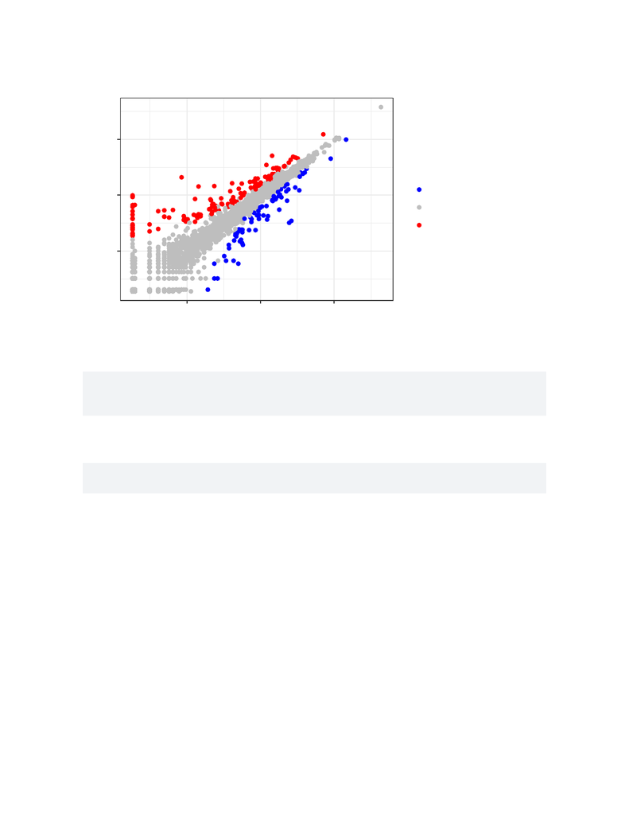

0

5

10

0 5 10

Control Expression

Drug Pressenence Expression

State

down

unchanging

up

Gene Expression changes upon drug treatment

#read in gapminder le

url <- "https://raw.githubusercontent.com/jennybc/gapminder/master/inst/extdata/gapminder.tsv"

gapminder <- read.delim(url)

#call dplyr library and lter for year 2007

# install.packages("dplyr") ## un-comment to install if needed

library(dplyr)

The following objects are masked from 'package:stats':

filter, lag

The following objects are masked from 'package:base':

intersect, setdiff, setequal, union

5

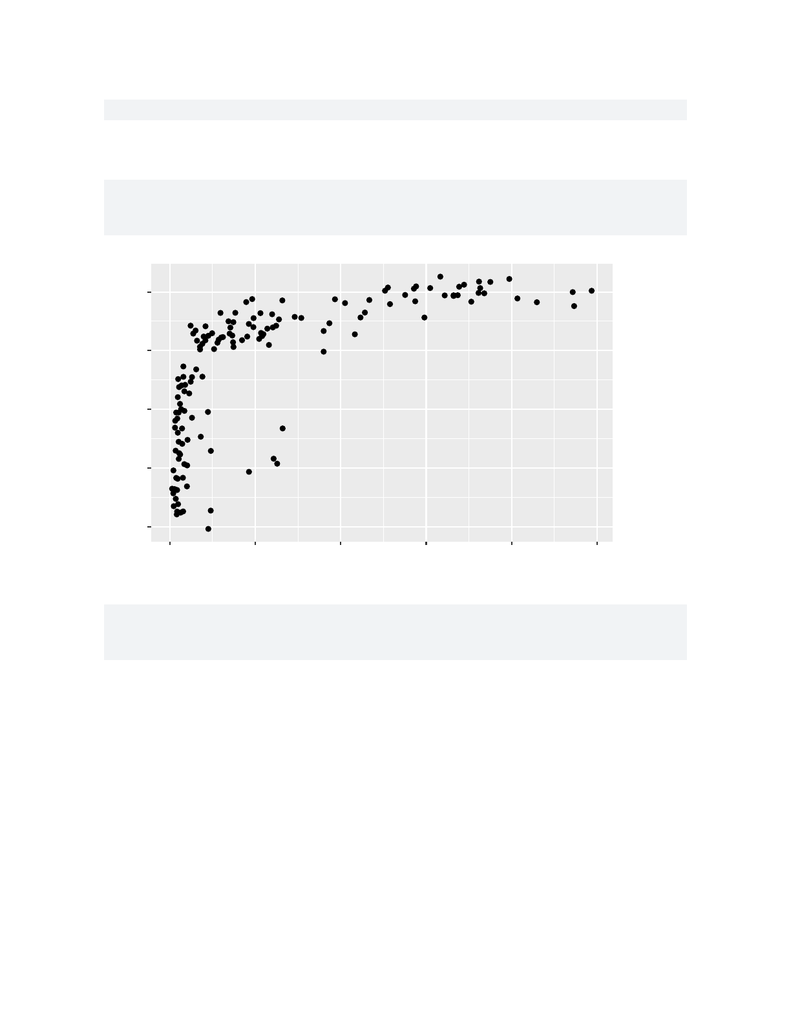

gapminder_2007 <- gapminder %>% filter(year==2007)

#plot

ggplot(gapminder_2007) +

aes(x=gdpPercap, y=lifeExp) +

geom_point()

40

50

60

70

80

0 10000 20000 30000 40000 50000

gdpPercap

lifeExp

ggplot(gapminder_2007) +

aes(x=gdpPercap, y=lifeExp, color=continent, size=pop) +

geom_point(alpha=0.5)

6

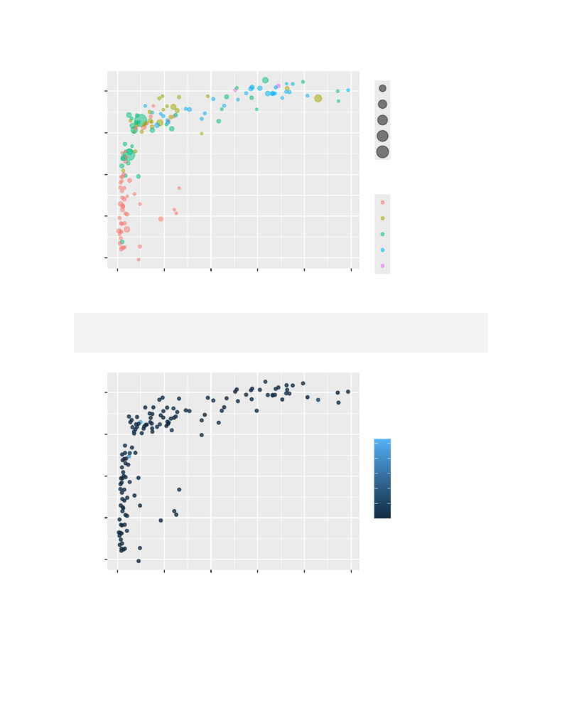

40

50

60

70

80

0 10000 20000 30000 40000 50000

gdpPercap

lifeExp

pop

2.50e+08

5.00e+08

7.50e+08

1.00e+09

1.25e+09

continent

Africa

Americas

Asia

Europe

Oceania

ggplot(gapminder_2007) +

aes(x = gdpPercap, y = lifeExp, color = pop) +

geom_point(alpha=0.8)

40

50

60

70

80

0 10000 20000 30000 40000 50000

gdpPercap

lifeExp

pop

2.50e+08

5.00e+08

7.50e+08

1.00e+09

1.25e+09

7

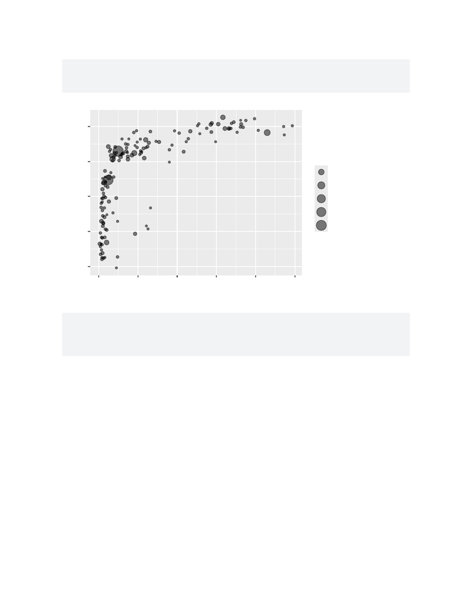

ggplot(gapminder_2007) +

aes(x = gdpPercap, y = lifeExp, size = pop) +

geom_point(alpha=0.5)

40

50

60

70

80

0 10000 20000 30000 40000 50000

gdpPercap

lifeExp

pop

2.50e+08

5.00e+08

7.50e+08

1.00e+09

1.25e+09

ggplot(gapminder_2007) +

geom_point(aes(x = gdpPercap, y = lifeExp,

size = pop), alpha=0.5) +

scale_size_area(max_size = 10)

8

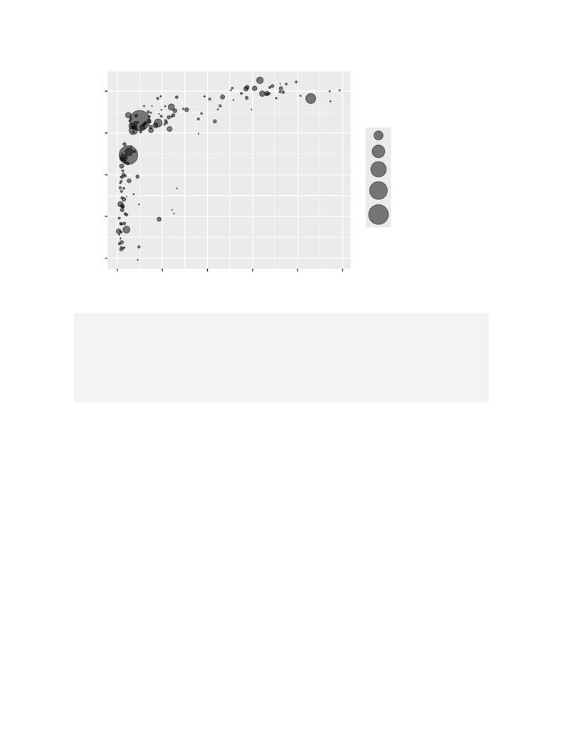

40

50

60

70

80

0 10000 20000 30000 40000 50000

gdpPercap

lifeExp

pop

2.50e+08

5.00e+08

7.50e+08

1.00e+09

1.25e+09

gapminder_1957 <- gapminder %>% filter(year==1957)

ggplot(gapminder_1957) +

aes(x = gdpPercap, y = lifeExp, color=continent,

size = pop) +

geom_point(alpha=0.7) +

scale_size_area(max_size = 10)

9

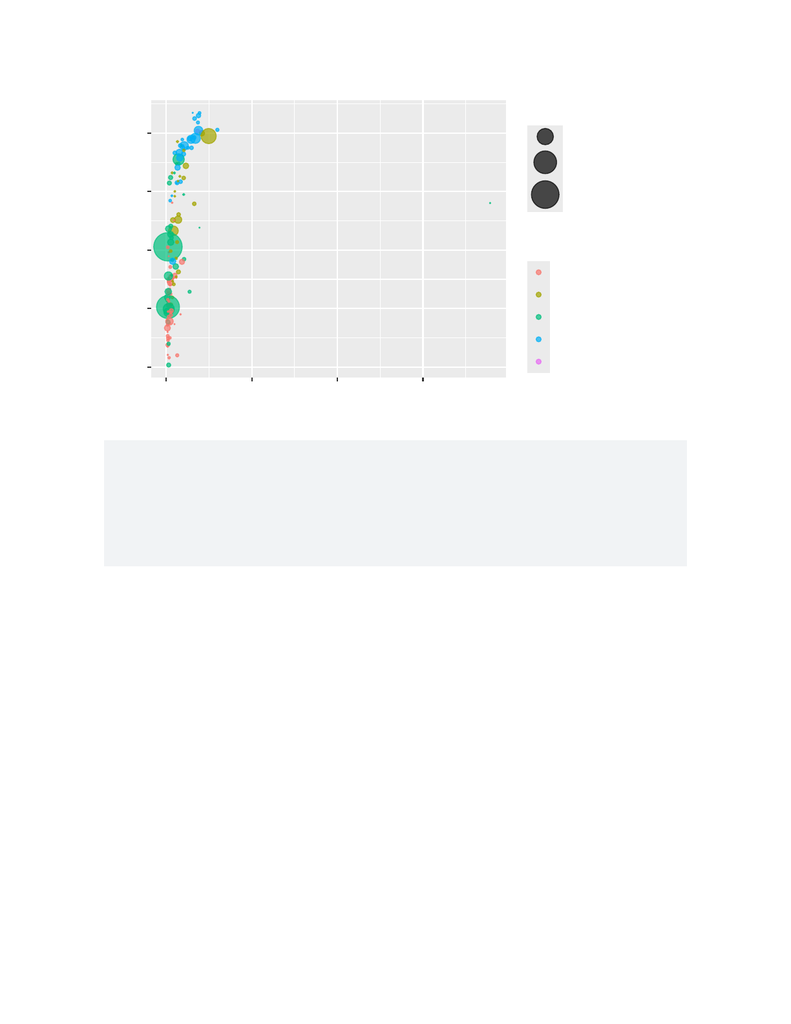

30

40

50

60

70

0 30000 60000 90000

gdpPercap

lifeExp

pop

2e+08

4e+08

6e+08

continent

Africa

Americas

Asia

Europe

Oceania

gapminder_1957 <- gapminder %>% filter(year==1957 | year==2007)

ggplot(gapminder_1957) +

geom_point(aes(x = gdpPercap, y = lifeExp, color=continent,

size = pop), alpha=0.7) +

scale_size_area(max_size = 10) +

facet_wrap(~year)

10

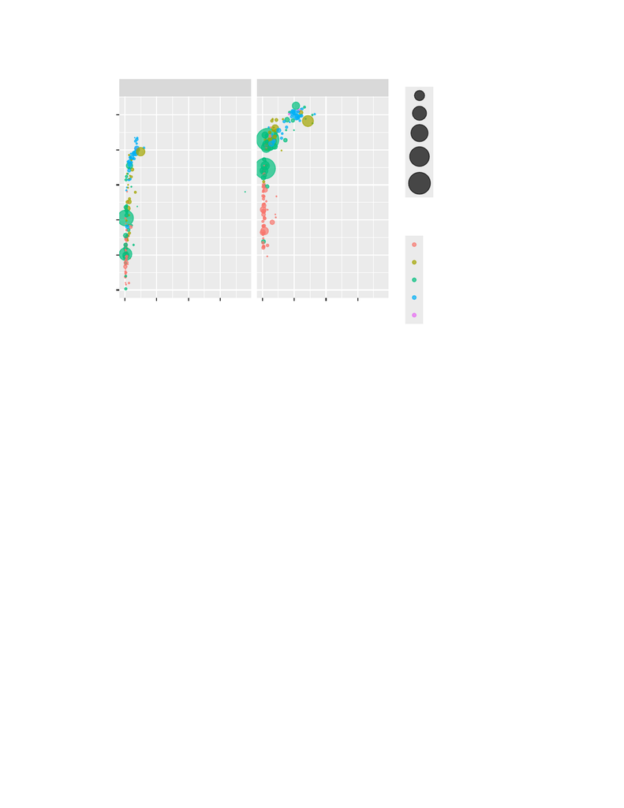

1957

2007

0 30000 60000 90000 0 30000 60000 90000

30

40

50

60

70

80

gdpPercap

lifeExp

pop

2.50e+08

5.00e+08

7.50e+08

1.00e+09

1.25e+09

continent

Africa

Americas

Asia

Europe

Oceania

11